# 3.1 Correlation analysis of PRISM data

gDR team

[gDR team](https://github.com/gdrplatform)

2026-06-01

[figure not shown]

3.1. Correlation analysis of PRISM data

**gDR Analysis Pipeline**

Date: 2026-06-01

Author: [gDR team](https://github.com/gdrplatform)

# 1 Introduction

This report performs a correlation analysis to identify potential biomarkers of drug sensitivity. It correlates the drug response metrics calculated in the previous steps (e.g., IC50, GR_AOC, synergy scores) with external datasets, such as genomic and transcriptomic data from the DepMap portal. The goal is to uncover relationships between molecular features (like gene expression or mutations) and sensitivity or resistance to the tested drugs.

```r
library(qs2)
library(purrr)
library(SummarizedExperiment)
library(data.table)
library(gDRutils)
library(gDRplots)
library(writexl)
```

# 2 Key Output Files

This report generates the **`tables`** folder, which is populated with Excel files containing the detailed results of the correlation analysis.

## 2.1 Full Association Results (in `tables/` folder)

These files contain the complete statistical results for every feature correlated.

- **`sa_depmap_assoc_tab_...xlsx`:** One file is created for each combination of drug, metric, and feature set (e.g., `sa_depmap_assoc_tab_RV__expression_all_genes_drug_A.xlsx`).
- **Content:** A table with all features (e.g., genes) as rows and statistical results as columns (`feature`, `rho`, `q_value`).
- **`combo_depmap_assoc_tab_...xlsx`:** The same as above, but for combination data.

## 2.2 Top Association Summaries (in `tables/` folder)

These files provide a convenient summary of only the most statistically significant hits from the analysis.

- **`sa_depmap_assoc_tab_summary_...xlsx`:** One file is created for each drug, summarizing the top hits (e.g., q-value < 0.05) across all its metrics, making it easier to identify the most promising biomarkers.
- **`combo_depmap_assoc_tab_summary_...xlsx`:** The same summary, but for the combination data.

# 3 Read the gDR MAE data

This section loads the final `MultiAssayExperiment` (MAE) object, which contains all the processed data and results from the previous step.

```r
wd <- "here::here()"
mae <- qs_read(file.path(wd, "gDR_data", "gDR_mae.qs2"))
```

# 4 Split SE objects into list of assays

This step converts the `SummarizedExperiment` objects into a user-friendly list of data tables for easier data handling in the following analysis.

```r
assay_list <- MAEpply(mae, function(x) {
  lst <- lapply(assayNames(x), function(y) convert_se_assay_to_dt(x, y,
                                                                  unify_metadata = TRUE,
                                                                  merge_additional_variables = TRUE))
  names(lst) <- assayNames(x)
  lst
})
```

# 5 Preparing assay data

The relevant data assays (`Averaged` and `Metrics`) are extracted from the list for the correlation analysis.

```r
sa_name <- get_supported_experiments("sa")

response_data_sa <- assay_list[[sa_name]][["Averaged"]]
response_metrics_sa <- assay_list[[sa_name]][["Metrics"]]
response_metrics_sa_capped <-
  cap_assay_infinities(conc_assay_dt = response_data_sa,
                       assay_dt = response_metrics_sa,
                       experiment_name = sa_name,
                       col = "xc50",
                       capping_fold = 5)
```

# 6 Correlation Analysis with DepMap by Drugs (Single-Agent Data)

This step analyzes gDR metrics against selected molecular features (e.g., gene expression, copy number) and metadata from the DepMap portal. For each drug, the analysis generates a panel of plots. The main **volcano plot** (left) visualizes the strength and significance of all correlations, while the **scatter/box plots** (right) show the raw data for the top 4 most significant hits.

**Main Volcano Plot (Left Side)**

Each volcano plot displays the results of correlating one drug sensitivity metric against a full set of molecular features (e.g., all genes in the expression dataset).

**What to look for:**

- **Significant Hits:** Points in the **top-left and top-right** corners of the plot are the most significant. They represent molecular features that are strongly correlated with drug response and pass the statistical significance threshold.
- **Effect Size (X-axis):** The x-axis (`rho`) represents the correlation coefficient. Points far to the **right** are features positively correlated with the metric (e.g., high gene expression is associated with high IC50, indicating resistance). Points far to the **left** are negatively correlated (e.g., high gene expression is associated with low IC50, indicating sensitivity).
- **Statistical Significance (Y-axis):** The y-axis represents the statistical significance (-log10 of the q-value). **The higher a point is on the plot, the more statistically significant** the correlation.
- **Data Tables:** A table of the top associations is provided below each plot for detailed review and can be downloaded as an Excel file.

**Top-Hit Plots (Right Side)**

These plots (usually 4) show the raw data for the top 4 most significant hits from the volcano plot on the left. The plot type depends on the molecular feature:

- **If the feature is numeric (e.g., Gene Expression):** A **scatter plot** is shown.
- **What to look for:** You should be able to see the correlation visually. If the ‘rho’ on the volcano plot was negative, the scatter plot should show a top-left to bottom-right trend. The red line is the line of best fit, and labeled points are the cell lines most influential in driving the correlation.
- **If the feature is categorical (e.g., Mutation Status):** A **boxplot** is shown.
- **What to look for:** Look for a clear difference in the median (the solid line in the box) between the groups (e.g., between “0” for wild-type and “1” for mutant). A significant hit on the volcano plot should correspond to a boxplot where the distributions are clearly different. The numbers on the x-axis `(N)` show the number of cell lines in each group.

```r
# omics feature set to be correlated
feature_sets <- c('OmicsExpressionProteinCodingGenesTPMLogp1', 'OmicsSomaticMutationsMatrixHotspot', 'OmicsSomaticMutationsMatrixDamaging', 'OmicsCNGene')
if (all(nchar(feature_sets) == 0)) {
  feature_sets <- info_feature_sets <- NULL
} else {
  info_feature_sets <-
    sprintf("The following molecular features were selected for analysis: %s.",
            paste(feature_sets, collapse = ", "))
}

metadata_columns <- c('OncotreeLineage', 'PatientRace')
if (all(nchar(metadata_columns) == 0)) {
  metadata_columns <- info_metadata_columns <- NULL
} else {
  info_metadata_columns <-
    sprintf("The following metadata columns were selected for analysis: %s.",
            paste(metadata_columns, collapse = ", "))
}
```

The following molecular features were selected for analysis: OmicsExpressionProteinCodingGenesTPMLogp1, OmicsSomaticMutationsMatrixHotspot, OmicsSomaticMutationsMatrixDamaging, OmicsCNGene.

The following metadata columns were selected for analysis: OncotreeLineage, PatientRace.

```r
drug_name_vec <- sort(unique(response_metrics_sa_capped[["DrugName"]]))
normalization_type_vec <- ifelse(FALSE, c("RV", "GR"), "RV")

obj_plot <- create_PRISM_plot_list_sa(drug_name_vec = drug_name_vec,
                                      dt_metrics = response_metrics_sa_capped,
                                      dt_average = response_data_sa,
                                      normalization_type_vec = normalization_type_vec,
                                      metric = c("x_mean", "xc50", "x_max"),
                                      meta_data_path = "raw_data/Model.csv",
                                      feat_data_path = "raw_data/meta",
                                      feature_sets = feature_sets,
                                      metadata_columns = metadata_columns,
                                      with_decoding = TRUE)
names(obj_plot[["ls_plot"]]) <-
  vapply(names(obj_plot[["ls_plot"]]), function(i) escape_special_characters(i),
         FUN.VALUE = character(1), USE.NAMES = FALSE)
names(obj_plot[["ls_assoc_data"]]) <-
  vapply(names(obj_plot[["ls_assoc_data"]]), function(i) escape_special_characters(i),
         FUN.VALUE = character(1), USE.NAMES = FALSE)
```

## 6.1 OmicsExpressionProteinCodingGenesTPMLogp1

### 6.1.1 GDC-8025

#### 6.1.1.1 Relative Viability

##### 6.1.1.1.1 RV_gDR_x_mean

🔍 Zoom In for Details

💾 Download Table

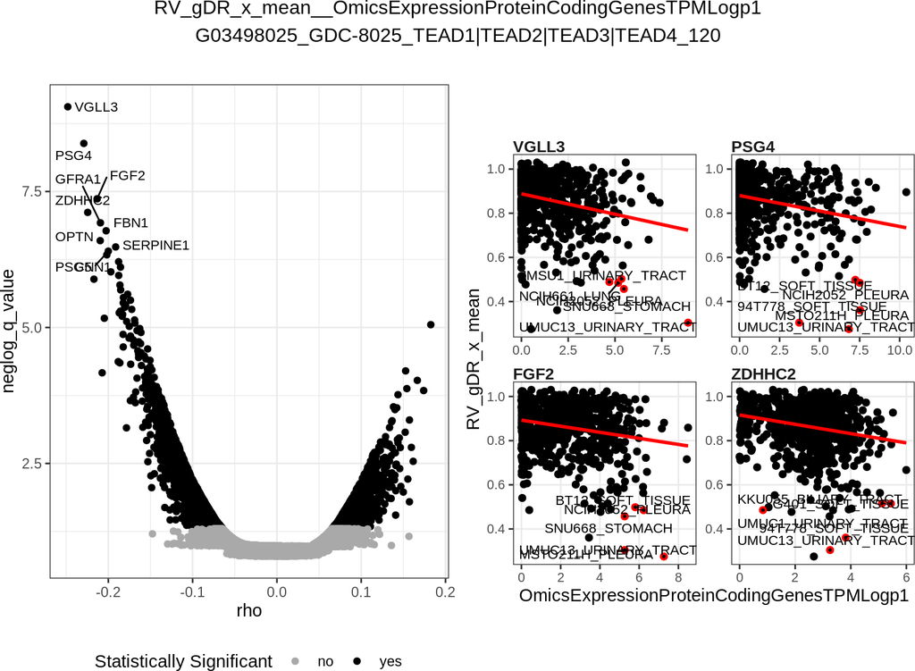

##### 6.1.1.1.2 RV_gDR_log10_xc50

🔍 Zoom In for Details

💾 Download Table

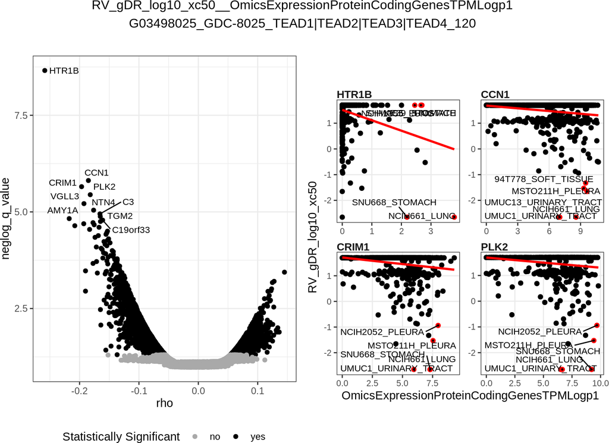

##### 6.1.1.1.3 RV_gDR_x_max

🔍 Zoom In for Details

💾 Download Table

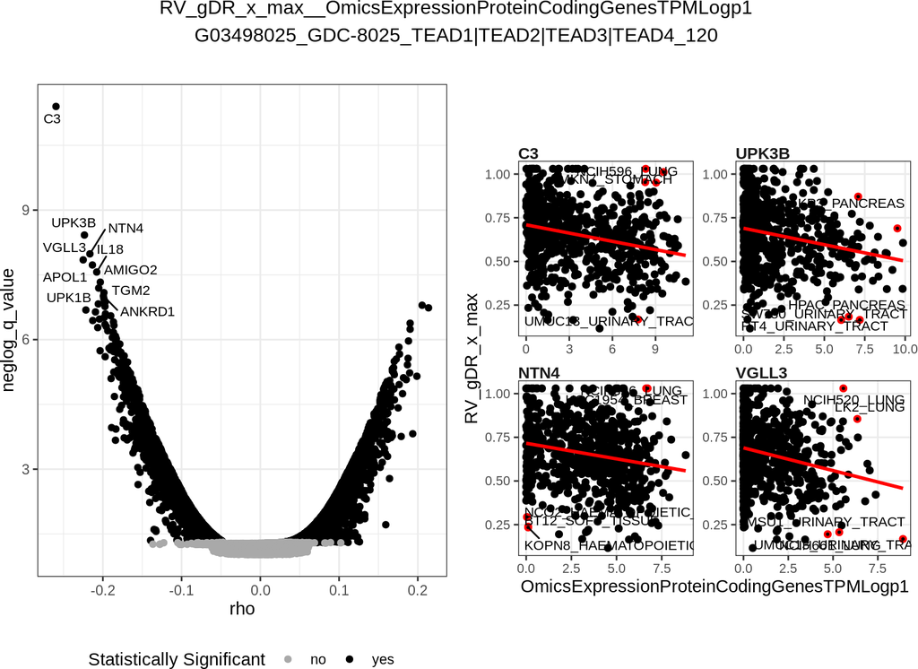

##### 6.1.1.1.4 RV_gDR_x_0.0111099984921913

🔍 Zoom In for Details

💾 Download Table

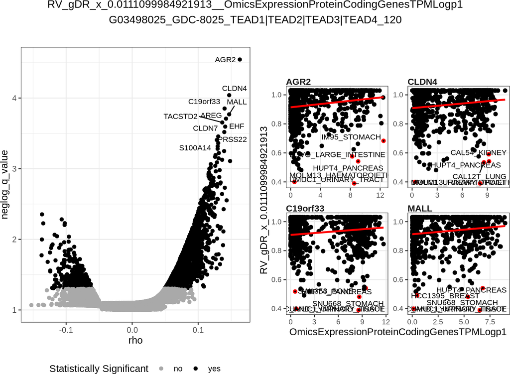

##### 6.1.1.1.5 RV_gDR_x_0.0411500152030233

🔍 Zoom In for Details

💾 Download Table

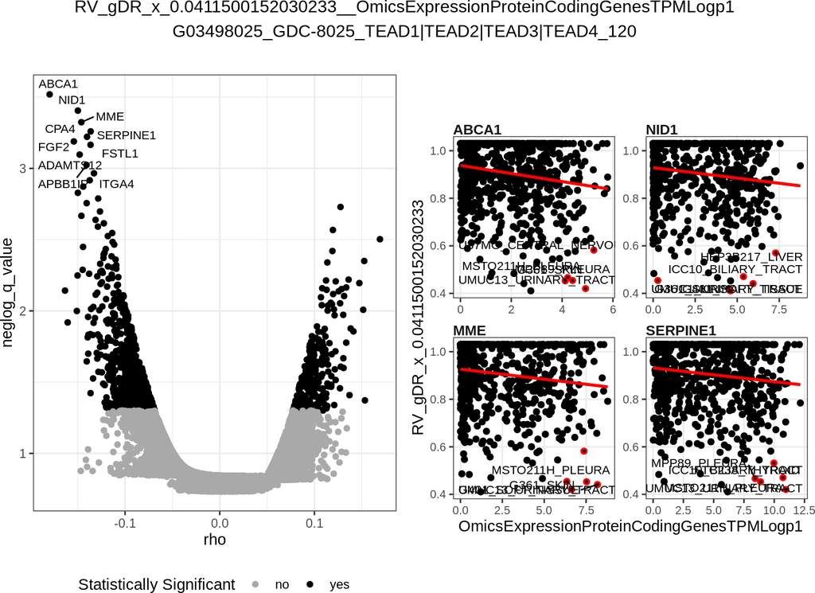

##### 6.1.1.1.6 RV_gDR_x_0.1

🔍 Zoom In for Details

💾 Download Table

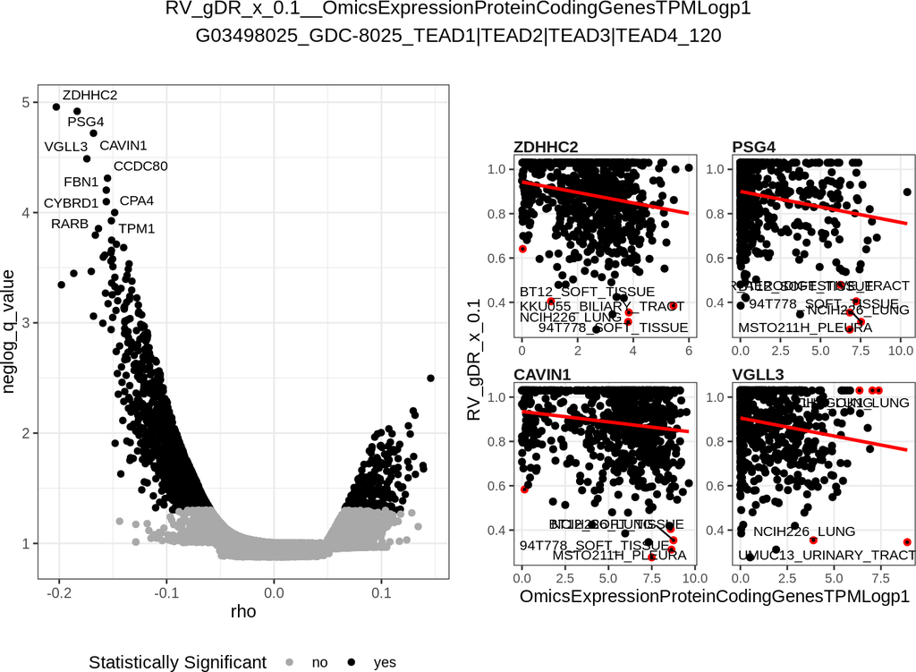

##### 6.1.1.1.7 RV_gDR_x_0.123500012058484

🔍 Zoom In for Details

💾 Download Table

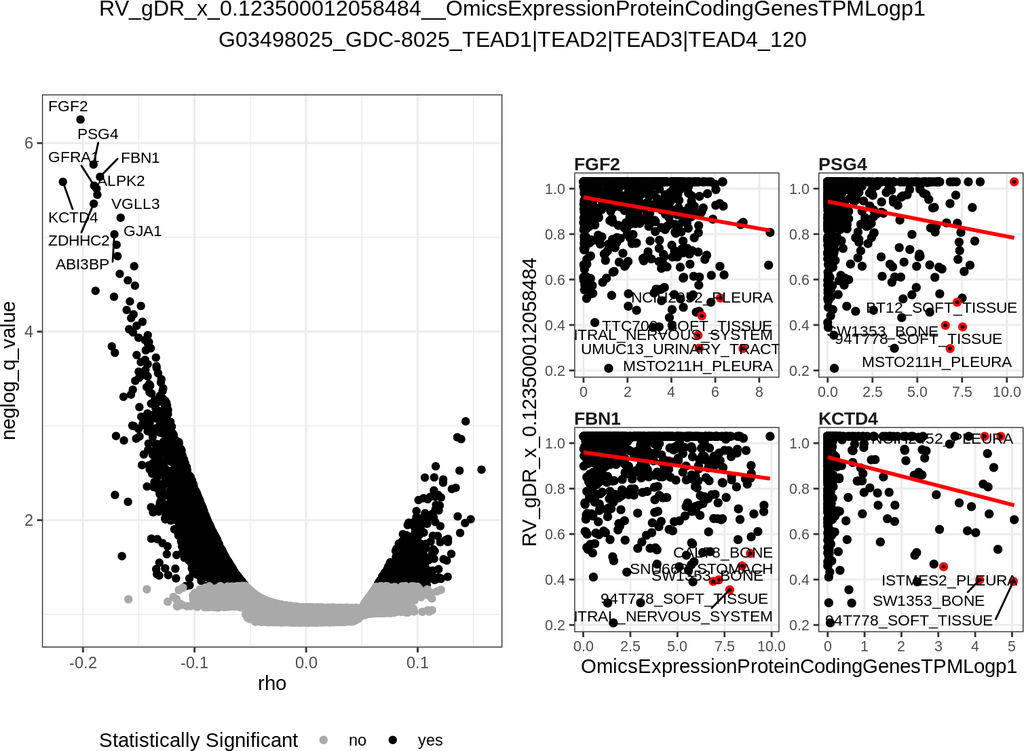

##### 6.1.1.1.8 RV_gDR_x_0.370400018754865

🔍 Zoom In for Details

💾 Download Table

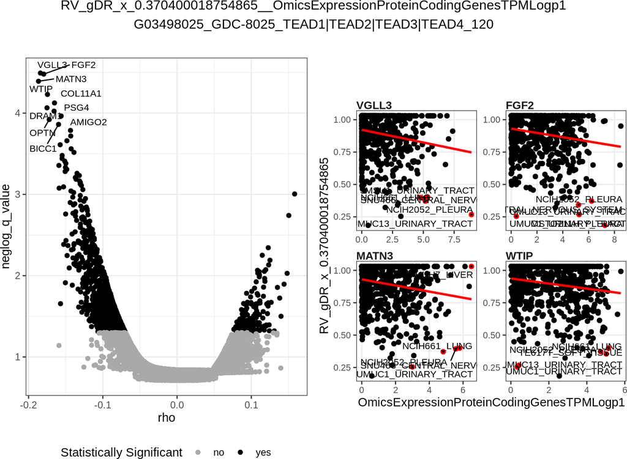

##### 6.1.1.1.9 RV_gDR_x_1.11099984921913

🔍 Zoom In for Details

💾 Download Table

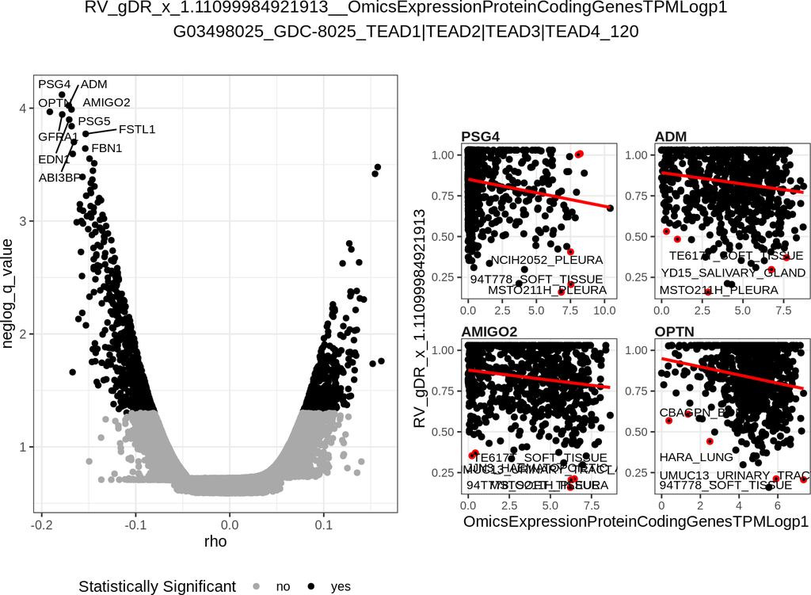

##### 6.1.1.1.10 RV_gDR_x_3.33299759280808

🔍 Zoom In for Details

💾 Download Table

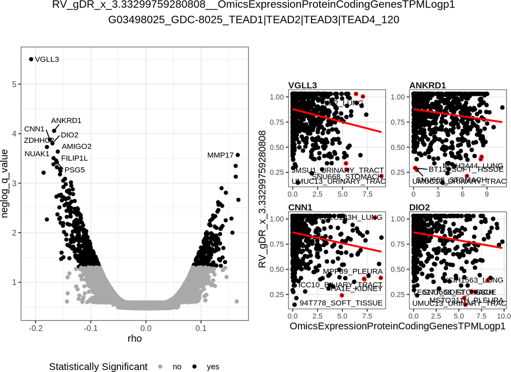

##### 6.1.1.1.11 RV_gDR_x_10

🔍 Zoom In for Details

💾 Download Table

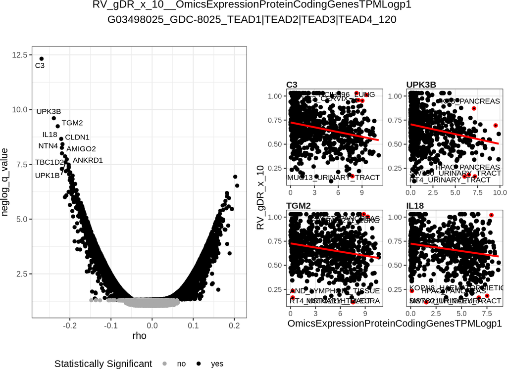

## 6.2 OmicsSomaticMutationsMatrixHotspot

### 6.2.1 GDC-8025

#### 6.2.1.1 Relative Viability

##### 6.2.1.1.1 RV_gDR_x_mean

🔍 Zoom In for Details

💾 Download Table

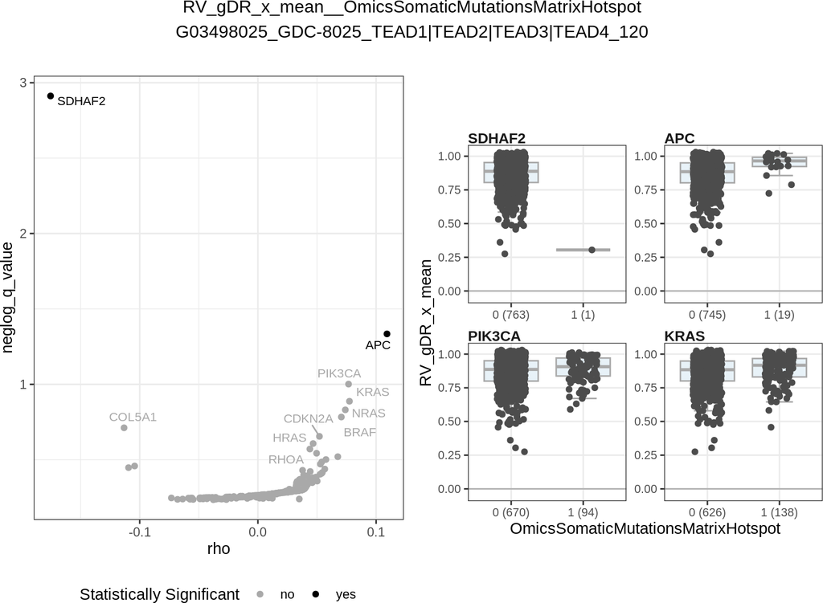

##### 6.2.1.1.2 RV_gDR_log10_xc50

🔍 Zoom In for Details

💾 Download Table

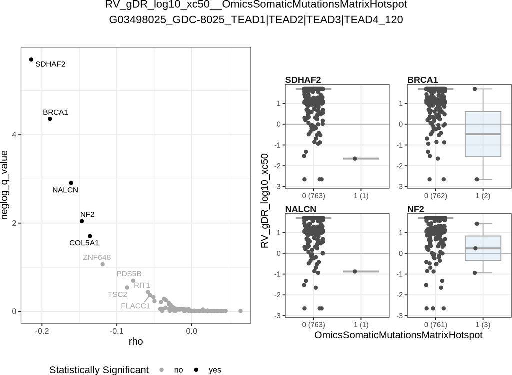

##### 6.2.1.1.3 RV_gDR_x_max

🔍 Zoom In for Details

💾 Download Table

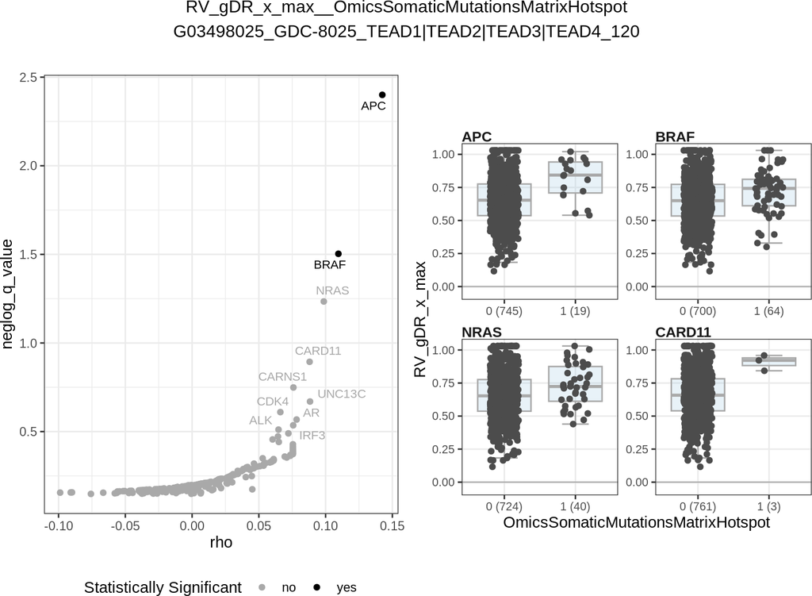

##### 6.2.1.1.4 RV_gDR_x_0.0111099984921913

🔍 Zoom In for Details

💾 Download Table

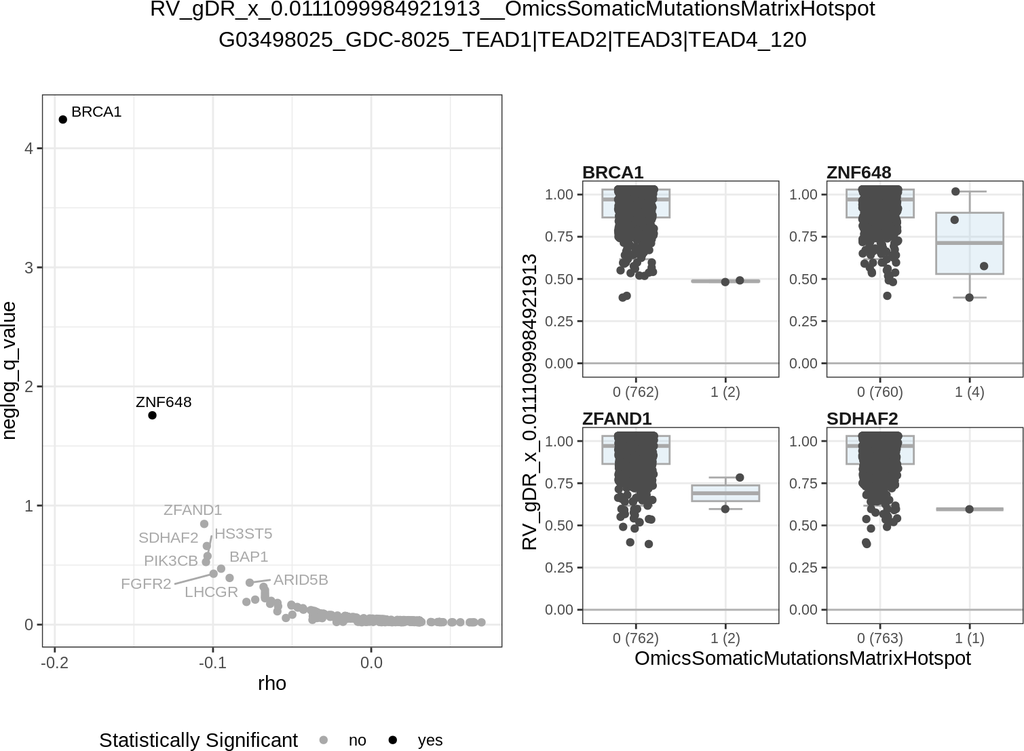

##### 6.2.1.1.5 RV_gDR_x_0.0411500152030233

🔍 Zoom In for Details

💾 Download Table

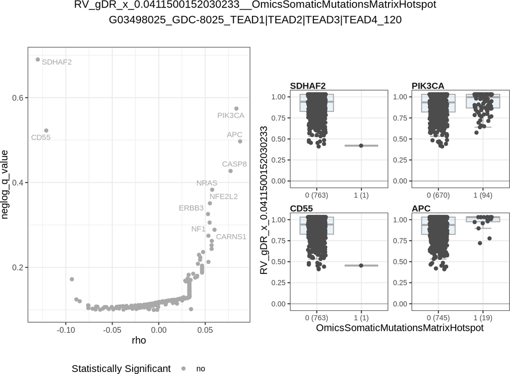

##### 6.2.1.1.6 RV_gDR_x_0.1

🔍 Zoom In for Details

💾 Download Table

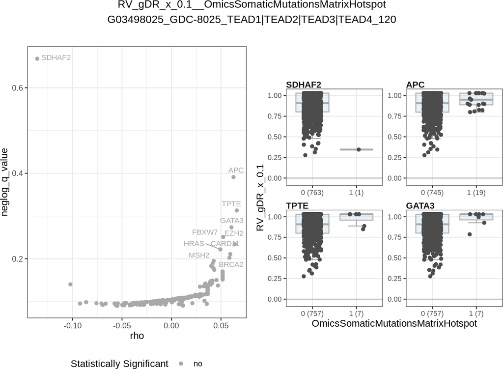

##### 6.2.1.1.7 RV_gDR_x_0.123500012058484

🔍 Zoom In for Details

💾 Download Table

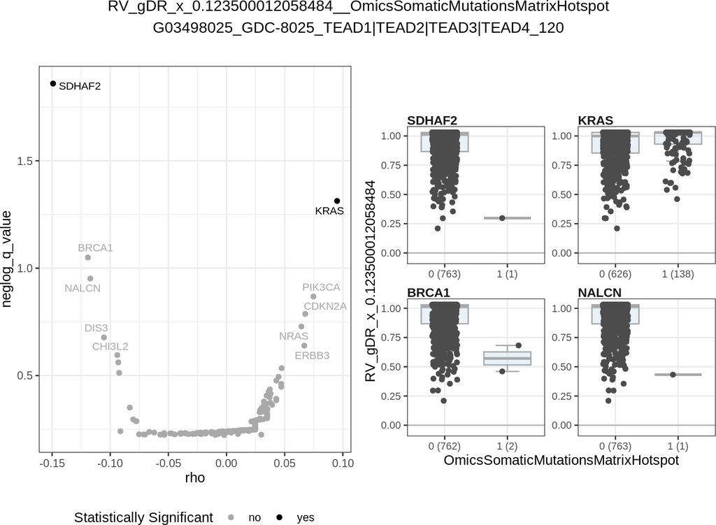

##### 6.2.1.1.8 RV_gDR_x_0.370400018754865

🔍 Zoom In for Details

💾 Download Table

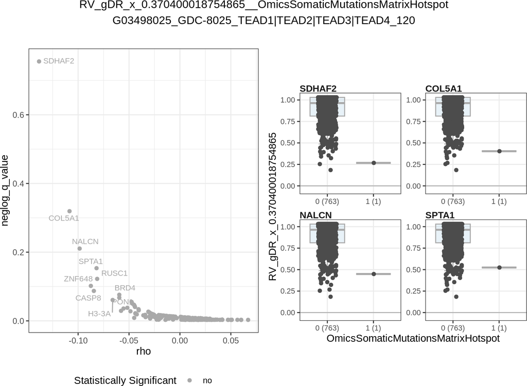

##### 6.2.1.1.9 RV_gDR_x_1.11099984921913

🔍 Zoom In for Details

💾 Download Table

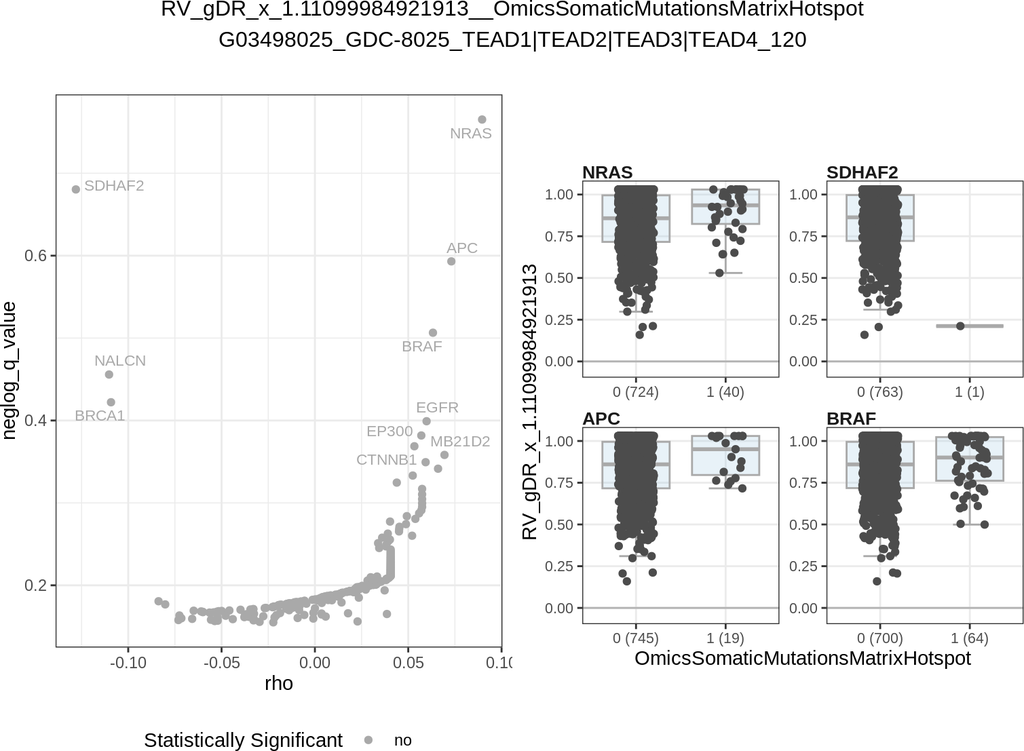

##### 6.2.1.1.10 RV_gDR_x_3.33299759280808

🔍 Zoom In for Details

💾 Download Table

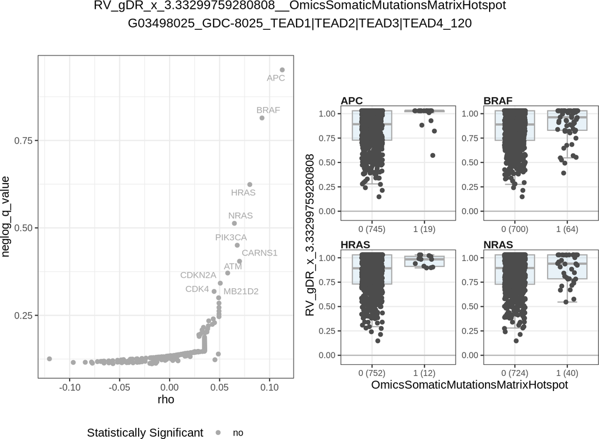

##### 6.2.1.1.11 RV_gDR_x_10

🔍 Zoom In for Details

💾 Download Table

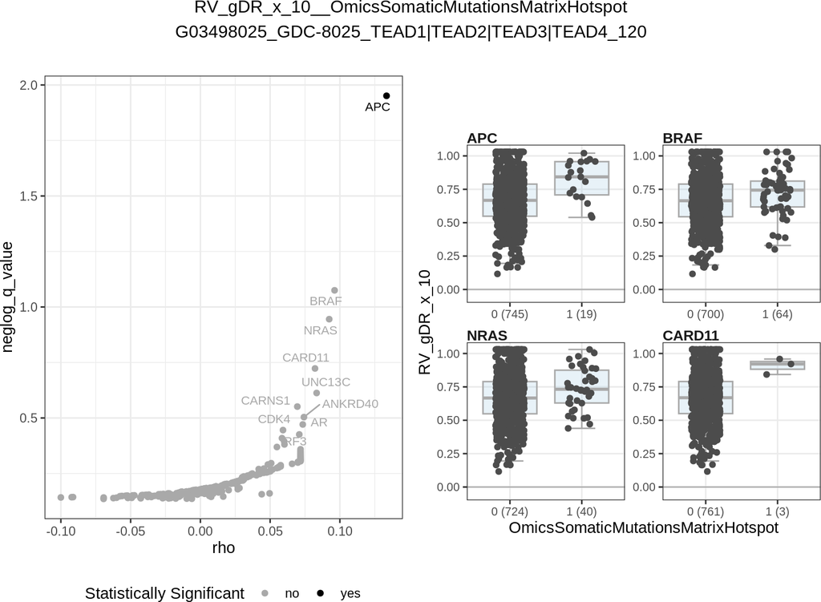

## 6.3 OmicsSomaticMutationsMatrixDamaging

### 6.3.1 GDC-8025

#### 6.3.1.1 Relative Viability

##### 6.3.1.1.1 RV_gDR_x_mean

🔍 Zoom In for Details

💾 Download Table

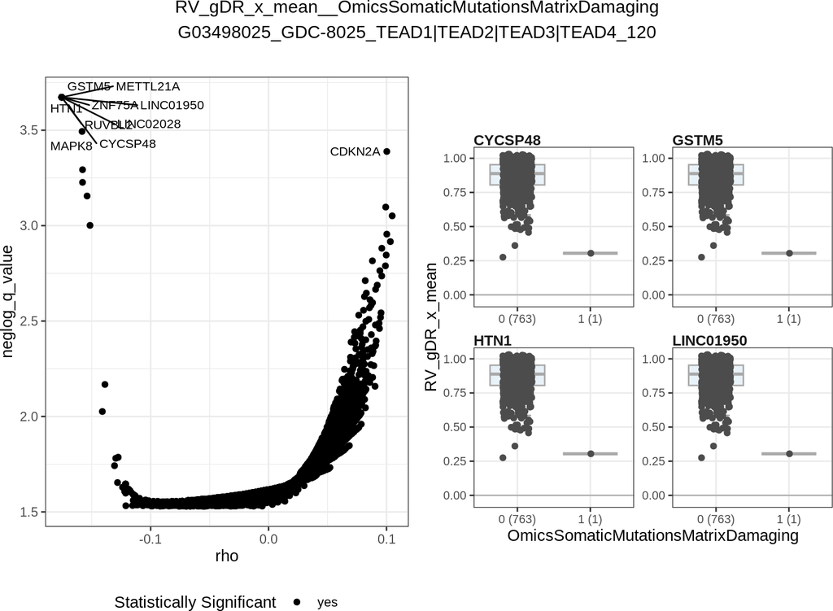

##### 6.3.1.1.2 RV_gDR_log10_xc50

🔍 Zoom In for Details

💾 Download Table

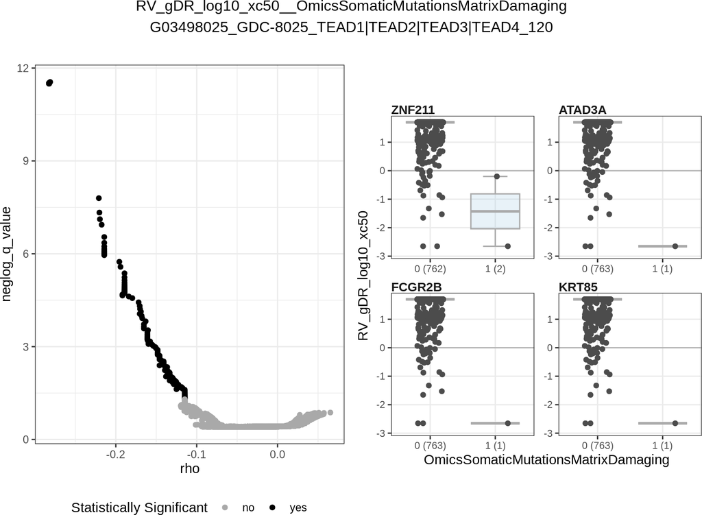

##### 6.3.1.1.3 RV_gDR_x_max

🔍 Zoom In for Details

💾 Download Table

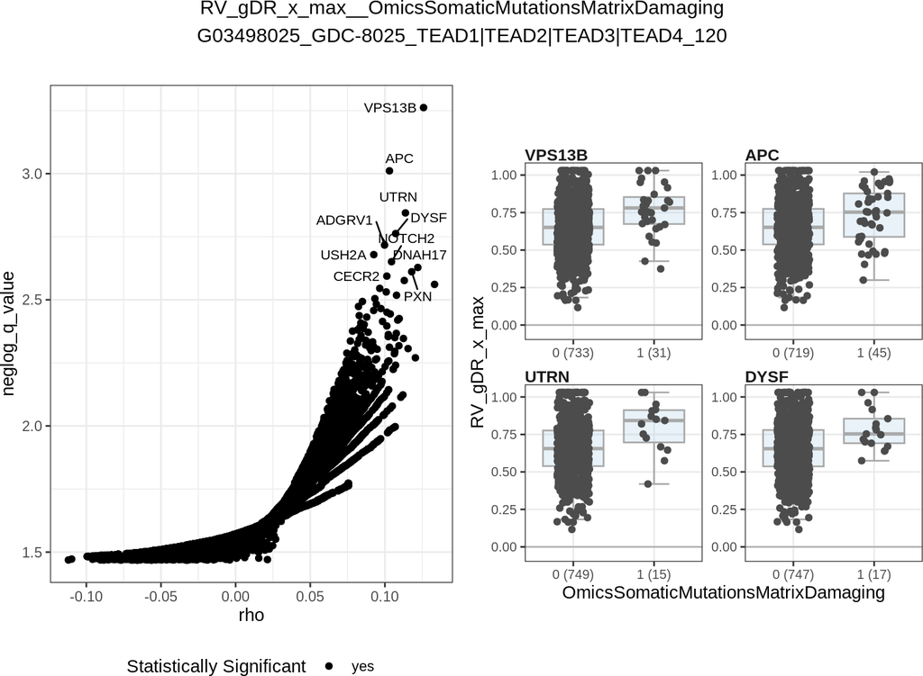

##### 6.3.1.1.4 RV_gDR_x_0.0111099984921913

🔍 Zoom In for Details

💾 Download Table

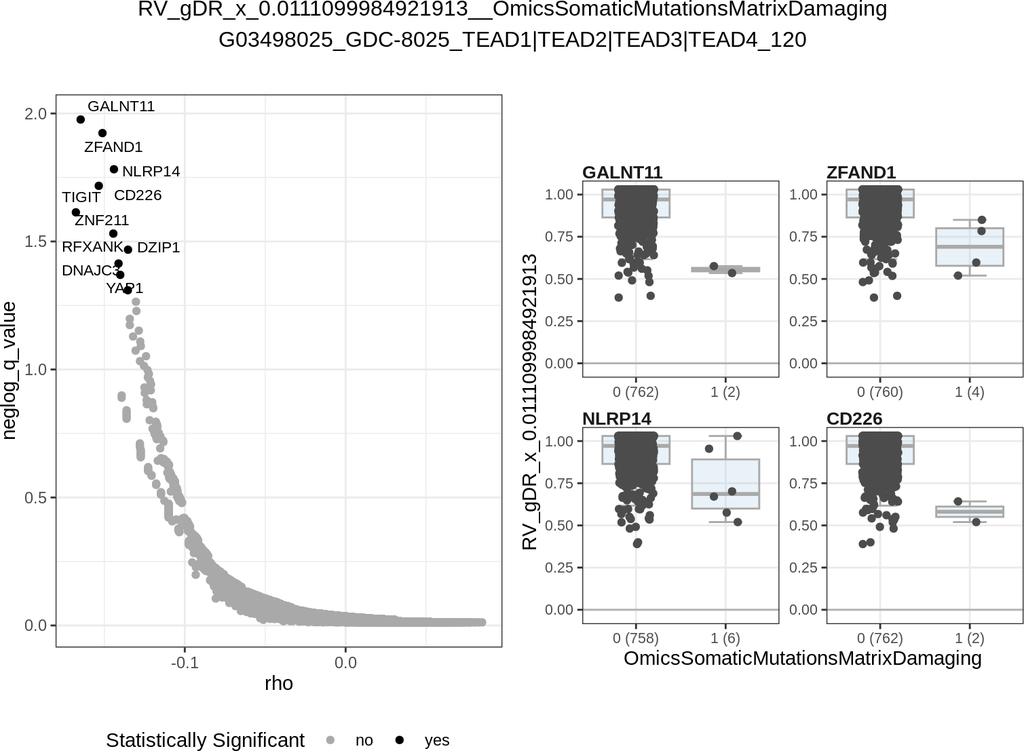

##### 6.3.1.1.5 RV_gDR_x_0.0411500152030233

🔍 Zoom In for Details

💾 Download Table

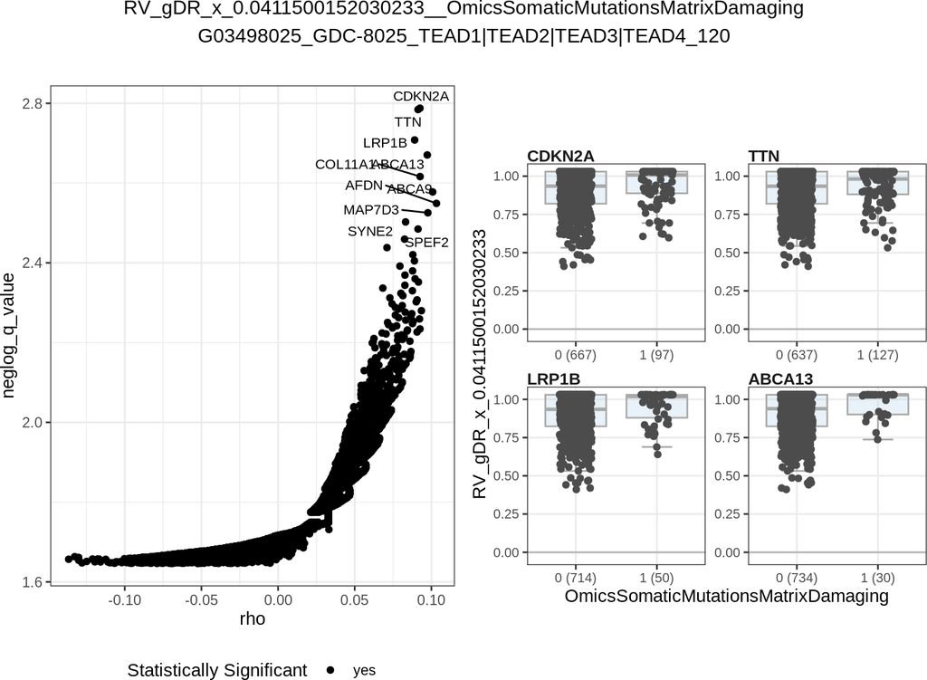

##### 6.3.1.1.6 RV_gDR_x_0.1

🔍 Zoom In for Details

💾 Download Table

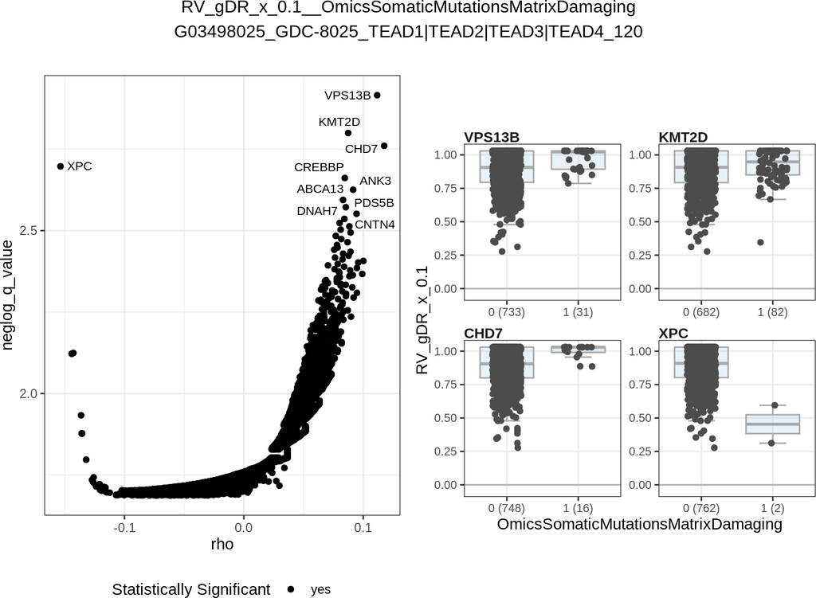

##### 6.3.1.1.7 RV_gDR_x_0.123500012058484

🔍 Zoom In for Details

💾 Download Table

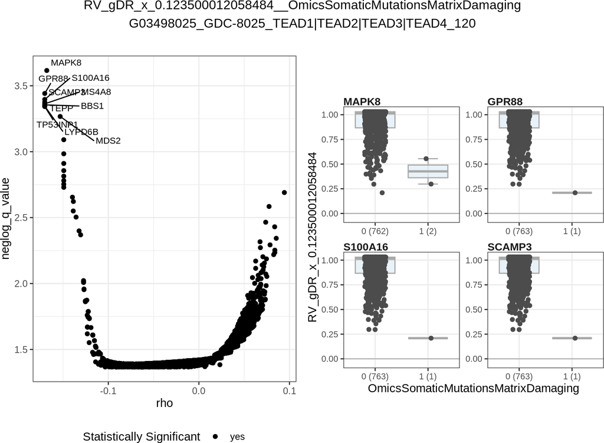

##### 6.3.1.1.8 RV_gDR_x_0.370400018754865

🔍 Zoom In for Details

💾 Download Table

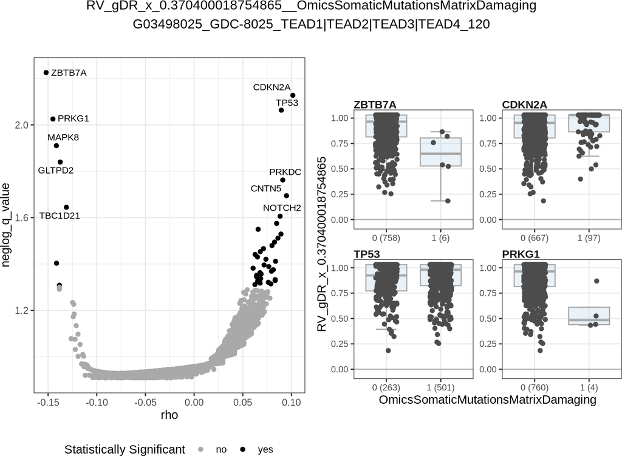